# Monthly Payment and Loan Amount Associated Factors

## by Olaoluwa Ebiekuraju

## Investigation Overview

In this investigation, I wanted to look at the factors associated with the prosper rating, loan amount and the monthly payment. The main focus were the loan details like; the quarter of the year the loan was borrowed, loan length and also the borrowers information like; owning a home or not and the anual income.

## Dataset Overview

This data set contained 113,937 loans with 81 variables on each loan. Only few of the variables were required for this analysis.

## Distribution of Monthly Loan Payment

The monthly payment in the dataset is positively skewed, with values ranging from \$0 at the lowest to about \$2560 at the highest. To eliminate outliers, it was plotted between the range of \$0 and \$600.

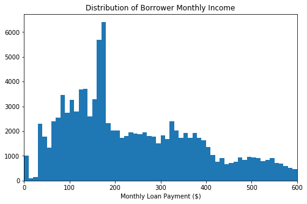

## Distribution of Loan Original Amount

The loan original amount is also positively skewed, ranging from \$1000 to \$35000. The conspicuous spikes in the frequencies of 2k, 3k, 4k, 5k, 10k, and 15k. To eliminate outliers, it was plotted between the range of \$800 and \$25400 with each bar set at \$200.

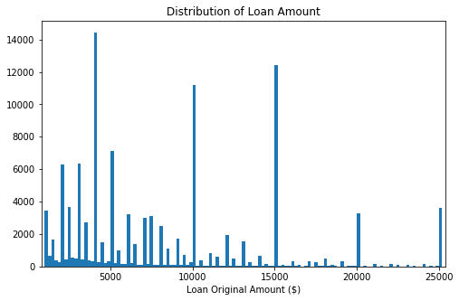

## Monthly Payment Vs. Loan Amount

The relationship is linear but splited into three major divisions which might be the influence of another very correlated variable.

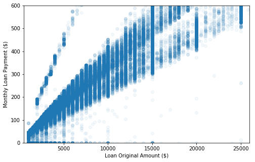

## Monthly Payment Vs. Loan Amount by Loan Length

There is an interaction effect visible between Monthly Payment, Loan Amount and Loan Length. Loan Length is the number of months the loan should last. Using color encoding to delineate the loan length in the scatter plot, it showed that monthly payment icreases with loan amount and decreases with the loan length.

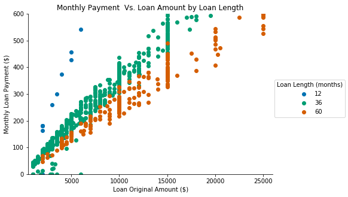

## Loan Amount Vs Quarter and Income Range

There is an interaction effect visible between Loan Amount and Quarter of the year the loan was lended out, and also Loan Amount and Income Range of the borrower. The average loan amount was higher in the first and last quarters of the year. It increases with increase in the annual income.

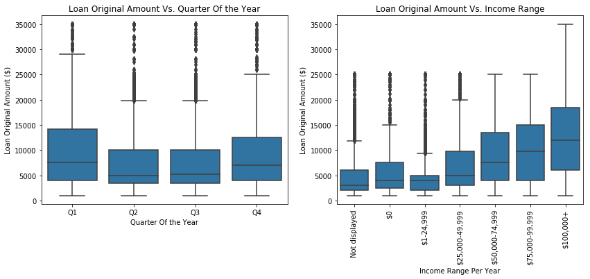

## Loan Amount Vs Quarter by Income Range

Those who earn 50k and above per annum borrow more money at the first and last quarters as compared to those earning less.

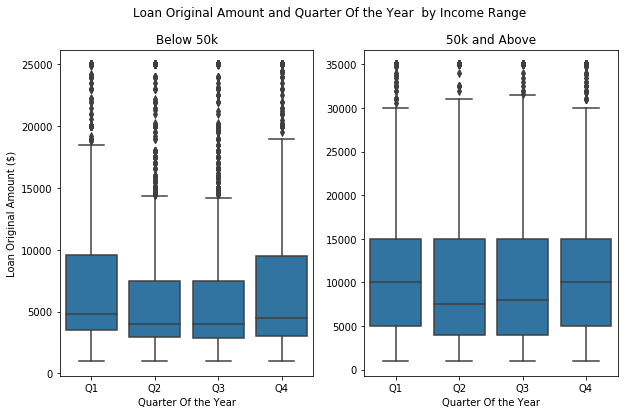

> In the classroom workspace, the generated HTML slideshow will be placed in the home folder.